# R for Data Science

홍우헌

quasar103@naver.com

2018-08-08

> Part 5  
> Communicate

R markdown의 notebook 모드는 분석가-분석가 소통에 사용하고 report 모드는 분석가-의사결정자 소통에 사용한다. R마크다운 포멧의 강력함 덕분에, 두 목적에 모두 같은 서류를 사용할 수 있다.

# 1 Chapter21: R Markdown

Git hub: http://happygitwithr.com/

# 2 Chapter22 : Graphics for Communication with ggplot2

## 2.1 Label

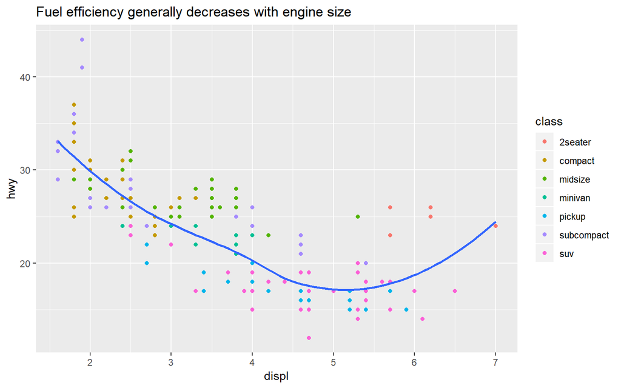

```r
ggplot(mpg, aes(displ, hwy)) +
  geom_point(aes(color = class)) +
  geom_smooth(se = FALSE) +
  labs(
    title =
      "Fuel efficiency generally decreases with engine size"
    )
```

단순히 플랏을 설명하는 제목은 피하자.

- subtitle은 제목아래에 더 작은 폰트에서 추가적인 세부사항을 더한다.
- caption은 데이터 출처를 설명하기에 이용되는 플랏의 오른쪽 밑에 텍스트를 추가한다.

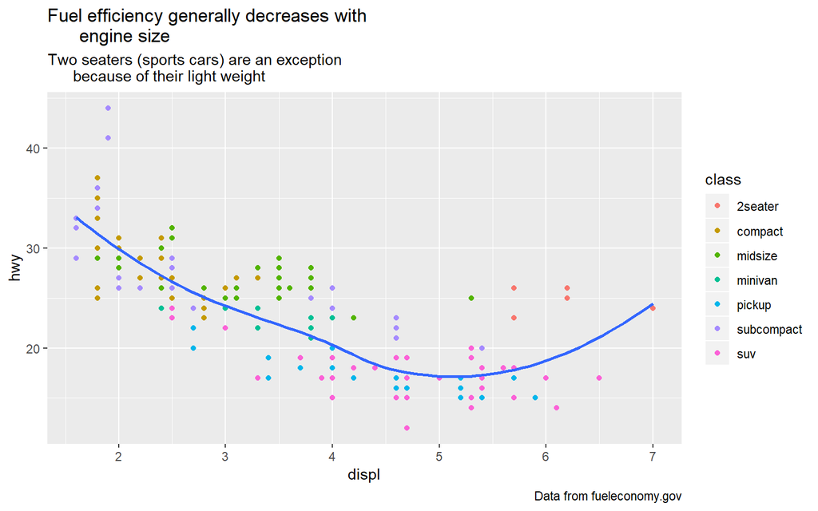

```r
ggplot(mpg, aes(displ, hwy)) +
  geom_point(aes(color = class)) +
  geom_smooth(se = FALSE) +
  labs(
    title =
      "Fuel efficiency generally decreases with
      engine size"
    ,
    subtitle =
      "Two seaters (sports cars) are an exception
      because of their light weight"
    ,
    caption = "Data from fueleconomy.gov"
  )
```

축과 범례 제목을 대체하기 위해 `labs()`를 사용할 수 있다. 짧은 변수 이름을 좀 더 상세한 설명으로 대체하고 단위를 포함하기 위해 좋은 아이디어이다.

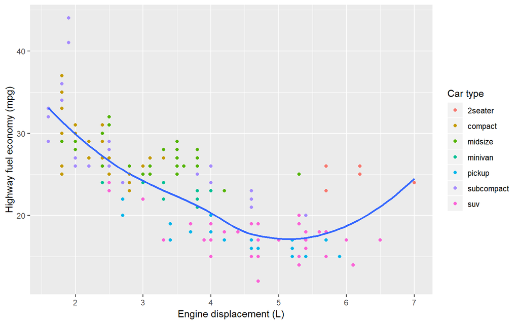

```r
ggplot(mpg, aes(displ, hwy)) +
  geom_point(aes(color = class)) +
  geom_smooth(se = FALSE) +
  labs(
    x = "Engine displacement (L)",
    y = "Highway fuel economy (mpg)",
    colour = "Car type"
  )
```

`?plotmath`을 참고하라.

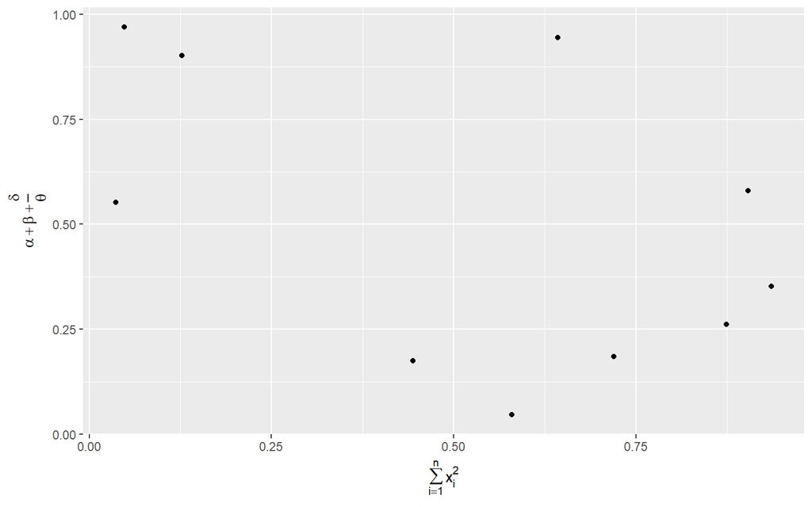

```r
df <- tibble(
  x = runif(10),
  y = runif(10)
)
ggplot(df, aes(x, y)) +
  geom_point() +
  labs(
    x = quote(sum(x[i] ^ 2, i == 1, n)),
    y = quote(alpha + beta + frac(delta, theta))
  )
```

## 2.2 Exercises

1. Create one plot on the fuel economy data with customized title, subtitle, caption, x, y, and colour labels.

[figure not shown]

```r
ggplot(data = mpg,
       mapping = aes(x = fct_reorder(class, hwy), y = hwy)) +
  geom_boxplot() +
  coord_flip() +
  labs(
    title = "Compact Cars have > 10 Hwy MPG than Pickup Trucks",
    subtitle = "Comparing the median highway mpg in each class",
    caption = "Data from fueleconomy.gov",
    x = "Car Class",
    y = "Highway Miles per Gallon"
  )
```

2. The geom_smooth() is somewhat misleading because the hwy for large engines is skewed upwards due to the inclusion of lightweight sports cars with big engines. Use your modeling tools to fit and display a better model.

[figure not shown]

```r
ggplot(mpg, aes(displ, hwy, colour = class)) +
  geom_point(aes(colour = class)) +
  geom_smooth(method = "lm", se = FALSE) +
  labs(
    title = "Fuel efficiency generally decreases with engine size",
    subtitle = "Subcompact cars show the greatest sensitivity to engine size",
    caption = "Data from fueleconomy.gov"
  )
```

[figure not shown]

```r
mod <- lm(hwy ~ class, data = mpg)
mpg %>%
  add_residuals(mod) %>%
  ggplot(aes(displ, resid)) +
  geom_point() +
  geom_smooth(method = "lm", se = FALSE) +
  labs(
    title = "Fuel efficiency decreases with engine size",
    subtitle = "Highway MPG for Cars After Subtracing Mean MPG of their Class",
    caption = "Data from fueleconomy.gov",
    x = "Highway MPG Relative to Class",
    y = "Engine Displacement"
  )
```

## 2.3 Annotations

플랏에 주요 성분을 라벨링 하는 것을 제외하고 개별 관측치나 그룹 관측치에 레이블 하는 것은 유용하다.

두 가지 가능한 레이블의 소스가 있다. 첫 번째는 레이블을 제공하는 df를 가졌을 때이다.

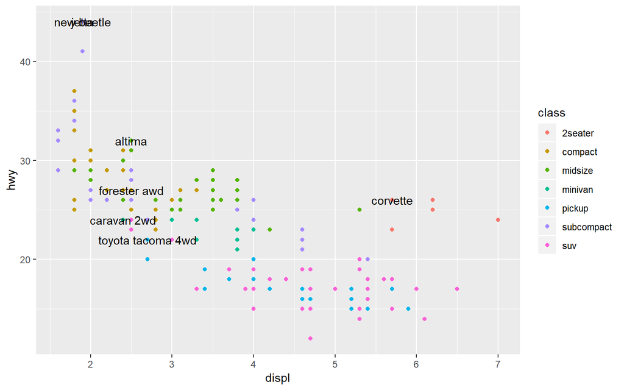

```r
best_in_class <- mpg %>%
  group_by(class) %>%
  filter(row_number(desc(hwy)) == 1)

ggplot(mpg, aes(displ, hwy)) +
  geom_point(aes(color = class)) +
  geom_text(aes(label = model), data = best_in_class)
```

텍스트가 겹치므로

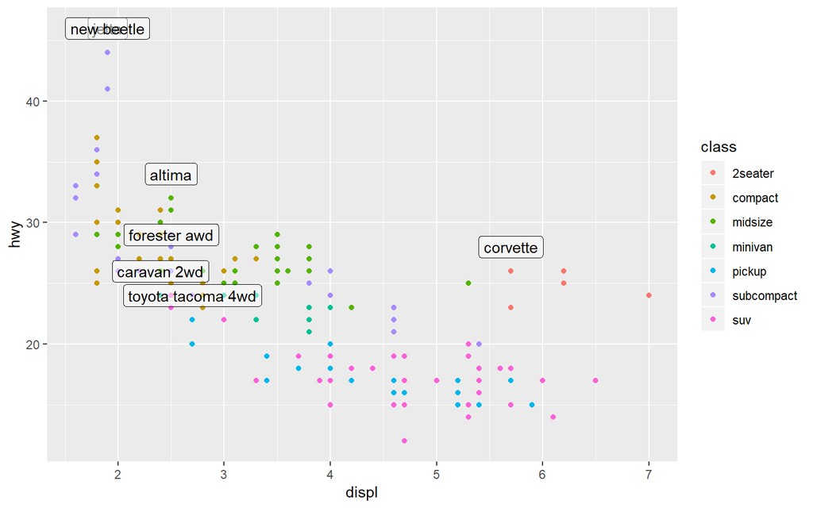

```r
ggplot(mpg, aes(displ, hwy)) +
  geom_point(aes(color = class)) +
  geom_label(
    aes(label = model),
    data = best_in_class,
    nudge_y = 2,
    alpha = 0.5
  )
```

여전히 겹치므로 `ggrepel::geom_label_repel()`사용

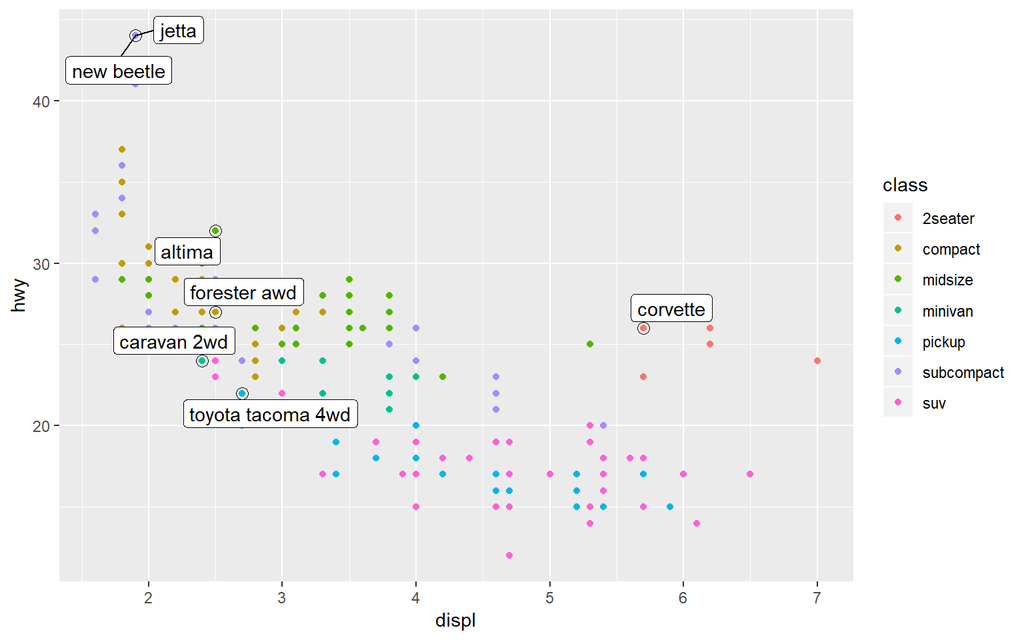

```r
ggplot(mpg, aes(displ, hwy)) +
  geom_point(aes(color = class)) +
  geom_point(size = 3, shape = 1, data = best_in_class) +
  ggrepel::geom_label_repel(
    aes(label = model),
    data = best_in_class
  )
```

범례를 레이블로 대체할 수도 있다. 이 플랏에서는 별로지만 그렇게 나쁘지는 않다.

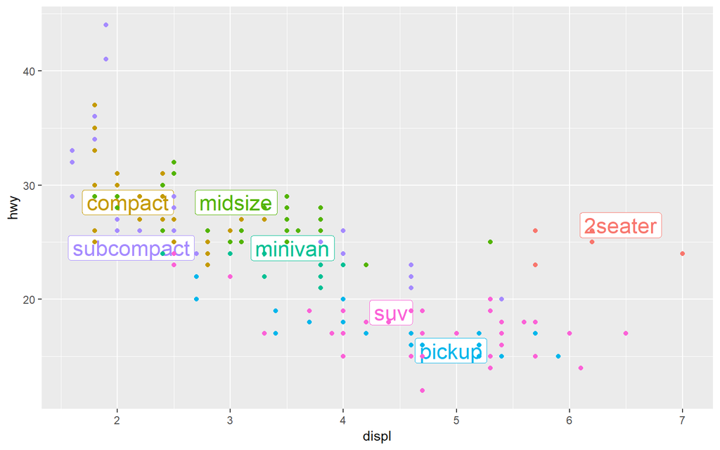

```r
class_avg <- mpg %>%
  group_by(class) %>%
  summarise(
    displ = median(displ),
    hwy = median(hwy)
  )

ggplot(mpg, aes(displ, hwy, color = class)) +
  ggrepel::geom_label_repel(aes(label = class),
                            data = class_avg,
                            size = 6,
                            label.size = 0,
                            segment.color = NA
                            ) + # 선 색깔이 안바뀌네..
  geom_point() +
  theme(legend.position = "none")
```

대안으로, 플랏에 단 하나의 레이블을 추가하고 싶을 수 있지만 여전이 df를 생성할 필요가 있다.

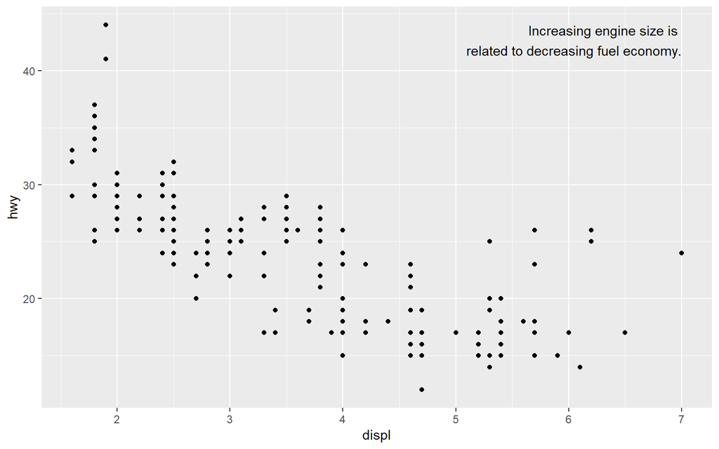

```r
label <- mpg %>%
  summarise(
    displ = max(displ),
    hwy = max(hwy),
    label = "Increasing engine size is \nrelated to decreasing fuel economy."
  )

ggplot(mpg, aes(displ, hwy)) +
  geom_point() +
  geom_text(
    aes(label = label),
    data = label,
    vjust = "top",
    hjust = "right"
  )
```

정확하게 플랏의 경계에 놓고 싶다면 Inf, -Inf를 사용해라.

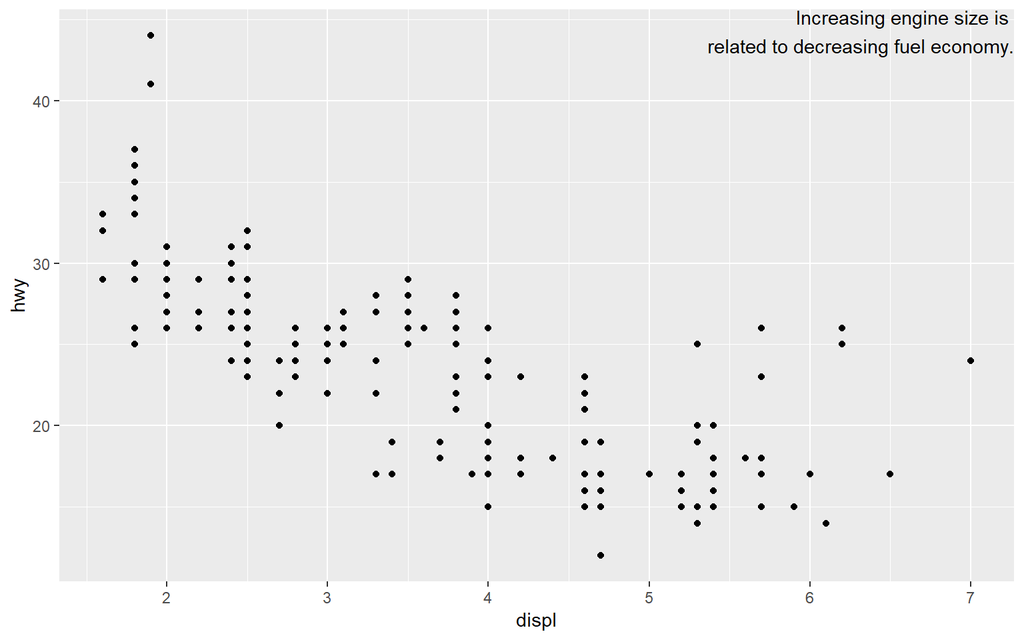

```r
label <- tibble(
  displ = Inf,
  hwy = Inf,
  label = "Increasing engine size is \nrelated to decreasing fuel economy."
)

ggplot(mpg, aes(displ, hwy)) +
  geom_point() +
  geom_text(
    aes(label = label),
    data = label,
    vjust = "top",
    hjust = "right"
  )
```

대신에 `str_wrap()`를 사용하면 자동으로 라인을 더해준다.

```
## Increasing engine size related to
## decreasing fuel economy.
```

[figure not shown]

```r
"Increasing engine size related to decreasing fuel economy." %>%
  stringr::str_wrap(width = 40) %>%
  writeLines()
```

- `geom_hline()`과 `geom_vline()`을 참조 선으로 추가하라. size = 2, color = white로 종종 그린다.
- `geom_rect()` 관심 있는 점들에 그린다.
- `geom_segment()` arrow인자를 가진다. x, y, xend, yend

## 2.4 Exercises

1. Use geom_text() with infinite positions to place text at the four corners of the plot.

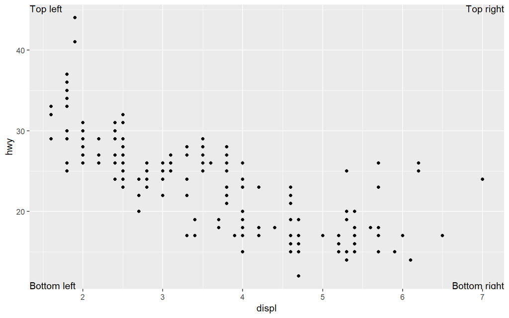

```r
label <- tribble(
  ~displ, ~hwy, ~label, ~vjust, ~hjust,
     Inf,  Inf,    "Top right", "top", "right",
     Inf, -Inf,    "Bottom right", "bottom", "right",
    -Inf,  Inf,    "Top left", "top", "left",
    -Inf, -Inf,    "Bottom left", "bottom", "left"
)

ggplot(mpg, aes(displ, hwy)) +
  geom_point() +
  geom_text(aes(label = label, vjust = vjust, hjust = hjust), data = label)
```

2. Read the documentation for annotate(). How can you use it to add a text label to a plot without having to create a tibble?

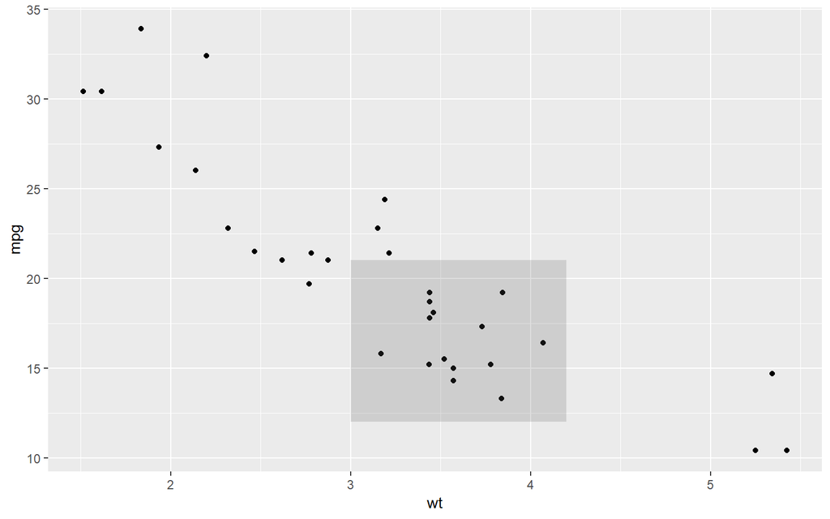

```r
p <- ggplot(mtcars, aes(x = wt, y = mpg)) + geom_point()
p + annotate("rect", xmin = 3, xmax = 4.2, ymin = 12, ymax = 21,
  alpha = .2)
```

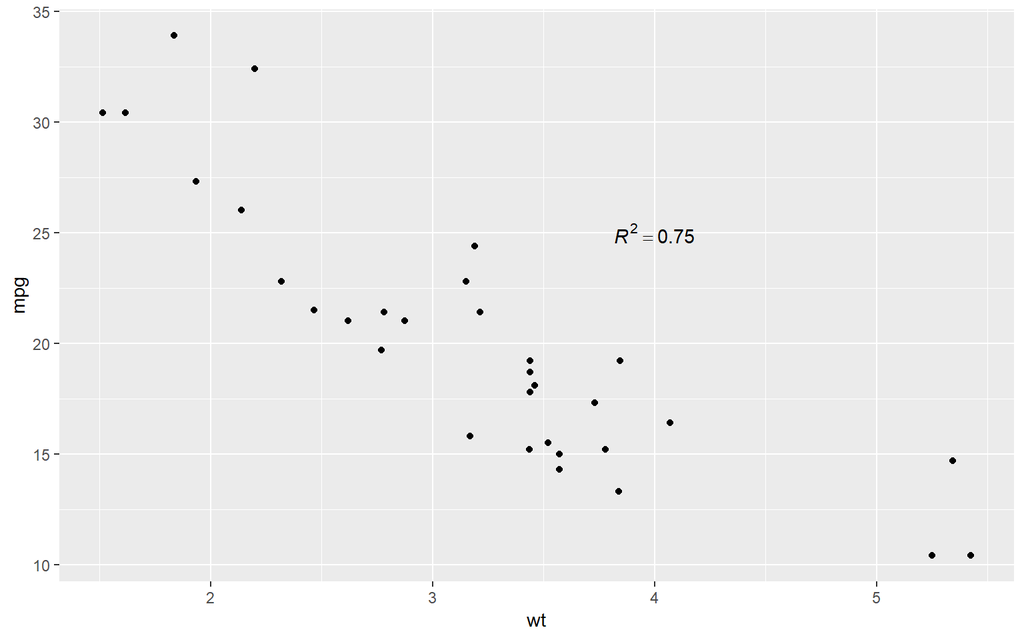

```r
p + annotate("text", x = 4, y = 25, label = "italic(R) ^ 2 == 0.75",
  parse = TRUE)
```

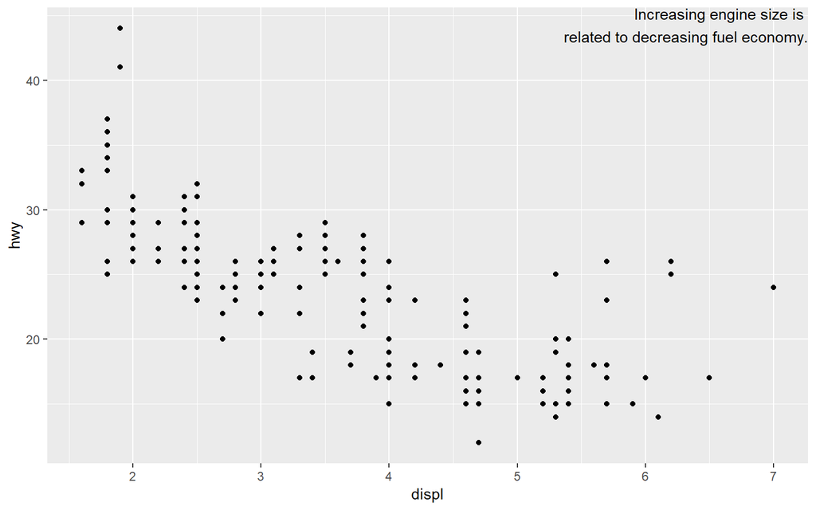

```r
ggplot(mpg, aes(displ, hwy)) +
  geom_point() +
  annotate("text", x = Inf, y = Inf,
           label = "Increasing engine size is \nrelated to decreasing fuel economy.", vjust = "top", hjust = "right")
```

기억!! 3. How do labels with geom_text() interact with faceting? How can you add a label to a single facet? How can you put a different label in each facet? (Hint: think about the underlying data.)

If the facet variable is not specified, the text is drawn in all facets

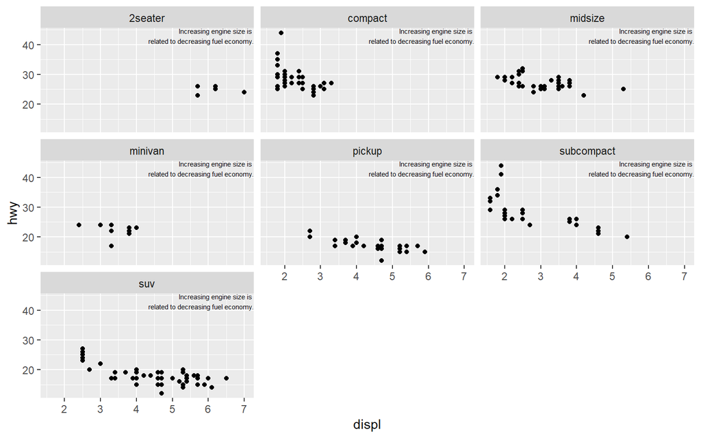

```r
label <- tibble(
  displ = Inf,
  hwy = Inf,
  label = "Increasing engine size is \nrelated to decreasing fuel economy."
)

ggplot(mpg, aes(displ, hwy)) +
  geom_point() +
  geom_text(aes(label = label), data = label, vjust = "top", hjust = "right",
            size = 2) +
  facet_wrap(~ class)
```

To draw the label in only one facet, add a column to the label data frame with the value of the faceting variable(s) in which to draw it.

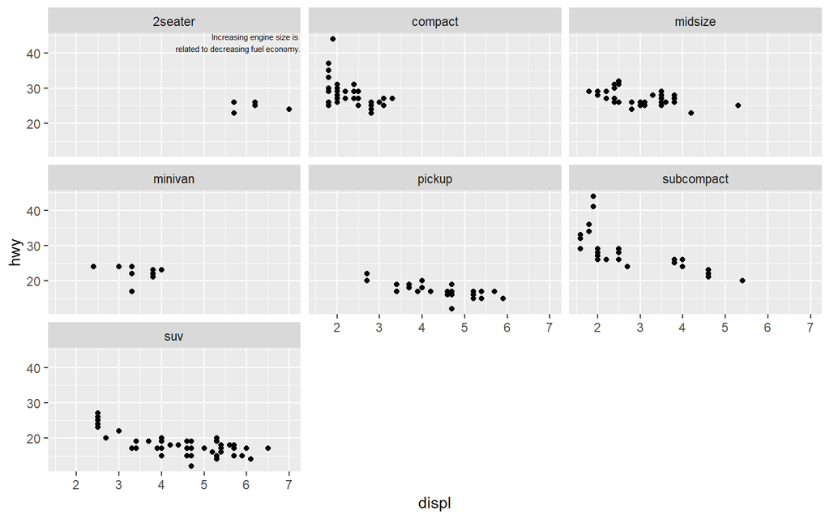

```r
label <- tibble(
  displ = Inf,
  hwy = Inf,
  class = "2seater",
  label = "Increasing engine size is \nrelated to decreasing fuel economy."
)

ggplot(mpg, aes(displ, hwy)) +
  geom_point() +
  geom_text(aes(label = label), data = label, vjust = "top", hjust = "right",
            size = 2) +
  facet_wrap(~ class)
```

To draw labels in different plots, simply have the facetting variable(s):

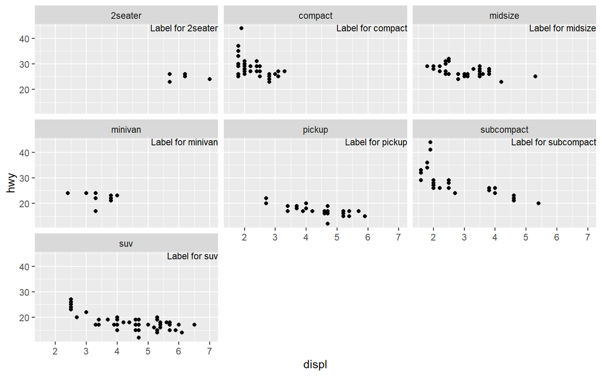

```r
label <- tibble(
  displ = Inf,
  hwy = Inf,
  class = unique(mpg$class),
  label = stringr::str_c("Label for ", class)
)

ggplot(mpg, aes(displ, hwy)) +
  geom_point() +
  geom_text(aes(label = label), data = label, vjust = "top", hjust = "right",
            size = 3) +
  facet_wrap(~ class)
```

4. What arguments to geom_label() control the appearance of the background box?
- `label.padding`: padding around label
- `label.r`: amount of rounding in the corners
- `label.size`: size of label border
5. What are the four arguments to arrow()? How do they work? Create a series of plots that demonstrate the most important options.

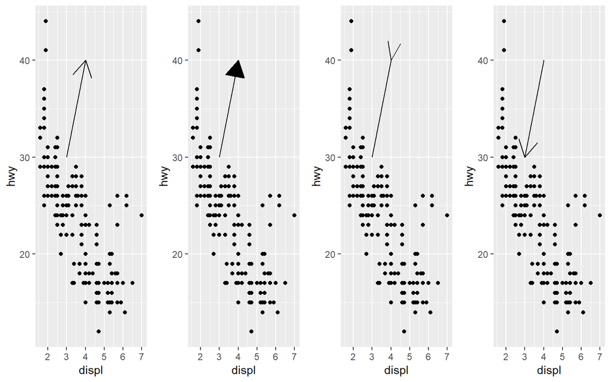

```r
g <- mpg %>%
  ggplot(aes(displ, hwy)) +
  geom_point()
grid.arrange(
g + geom_segment(x = 3, xend = 4, y = 30, yend = 40,
               arrow = arrow()),
g + geom_segment(x = 3, xend = 4, y = 30, yend = 40,
               arrow = arrow(type = "closed")),
g + geom_segment(x = 3, xend = 4, y = 30, yend = 40,
               arrow = arrow(angle = 160)),
g +  geom_segment(x = 3, xend = 4, y = 30, yend = 40,
               arrow = arrow(ends = "first")),
ncol = 4)
```

## 2.5 Scales

```r
ggplot(mpg, aes(displ, hwy)) +
  geom_point(aes(color = class))
```

```r
ggplot(mpg, aes(displ, hwy)) +
  geom_point(aes(color = class)) +
  scale_x_continuous() +
  scale_y_continuous() +
  scale_color_discrete()
```

### 2.5.1 Axis Ticks and Legend Keys

breaks는 눈금의 위치를 조정하고 key와 관련된 값을 조정한다. labels는 각 눈금/키와 관련된 텍스트 레이블을 조정한다.

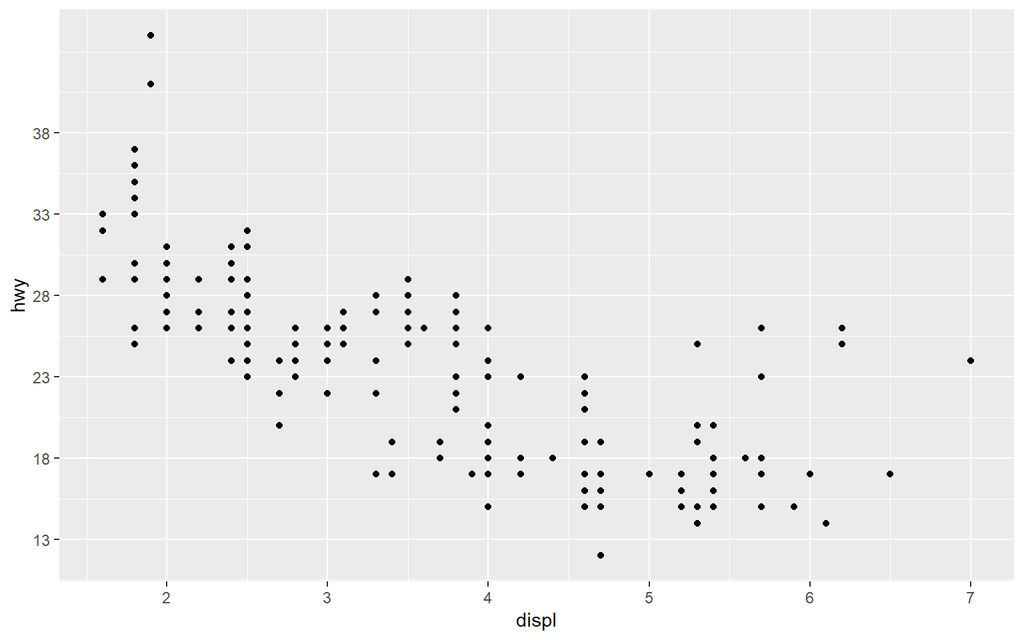

```r
ggplot(mpg, aes(displ, hwy)) +
  geom_point() +
  scale_y_continuous(breaks = seq(13, 40, by = 5))
```

label을 NULL로 설정함으로써 레이블을 제거할 수 있다. 이것은 지도나 absolute number를 공유하지 못하는 곳에서 플랏을 발표할 때이다.

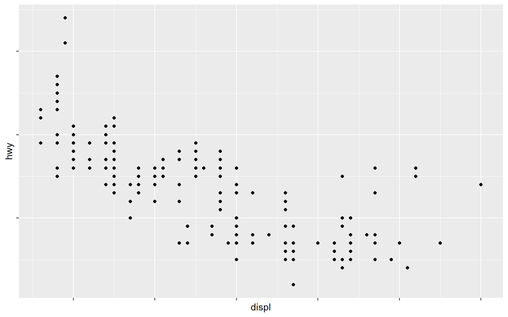

```r
ggplot(mpg, aes(displ, hwy)) +
  geom_point() +
  scale_x_continuous(labels = NULL) +
  scale_y_continuous(labels = NULL)
```

또한 breaks와 labels를 범례의 모습을 조정하기 위해 사용할 수 있다. 축과 범례를 합쳐서 guides라고 부른다. 축은 x와 y 미적요소에 이용된다. 범례는 다른 모든 것에 이용된다.

brekas의 다른 사용법은 상대적으로 적은 데이터를 가질 때 관측치가 존재하는 곳을 정확하게 강조하고 싶을 때이다. 예를 들어, 각 US 대통령이 임기를 시작하고 끝나는 것을 보여주는 플랏을 취하자.

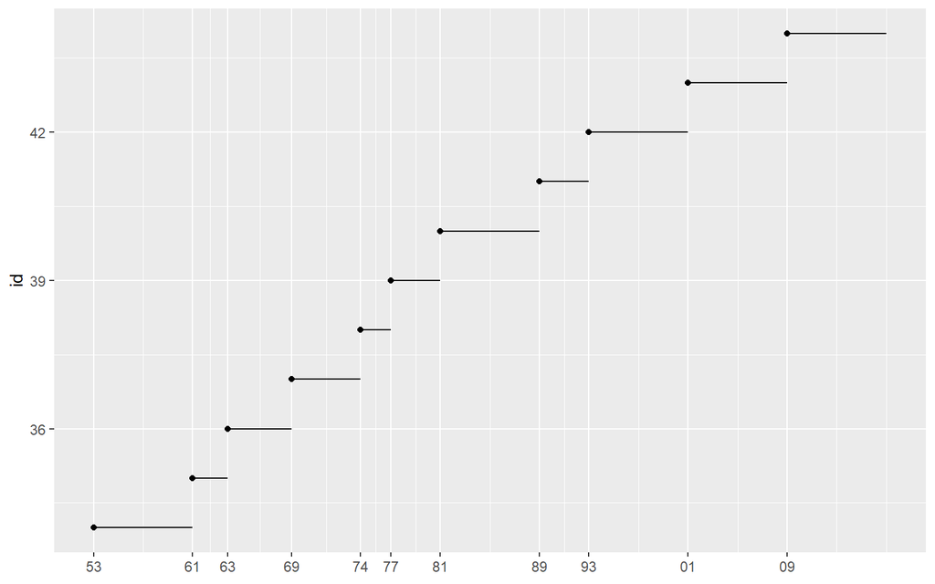

```r
presidential %>%
  mutate(id = 33 + row_number()) %>%  # 첫 행이 34대 대통령
  ggplot(aes(start, id)) +
    geom_point() +
    geom_segment(aes(xend = end, yend = id)) +
    scale_x_date(
      NULL,
      breaks = presidential$start,
      date_labels = "%y"
    )
```

날짜와 날짜-시간에 대한 breaks와 labels의 사양은 다소 다르다

- `date_labels`는 포멧 사양을 취한다. `parse_datetime()`와 같은 형태.
- `date_breaks`는 “2 days” or “1 month”같은 문자열을 취한다.

### 2.5.2 Legend Layout

범례의 전반적인 위치를 조정하기 위해, `theme()`설정을 사용할 필요가 있다. theme은 플랏의 데이터가 아닌 부분을 통제한다.

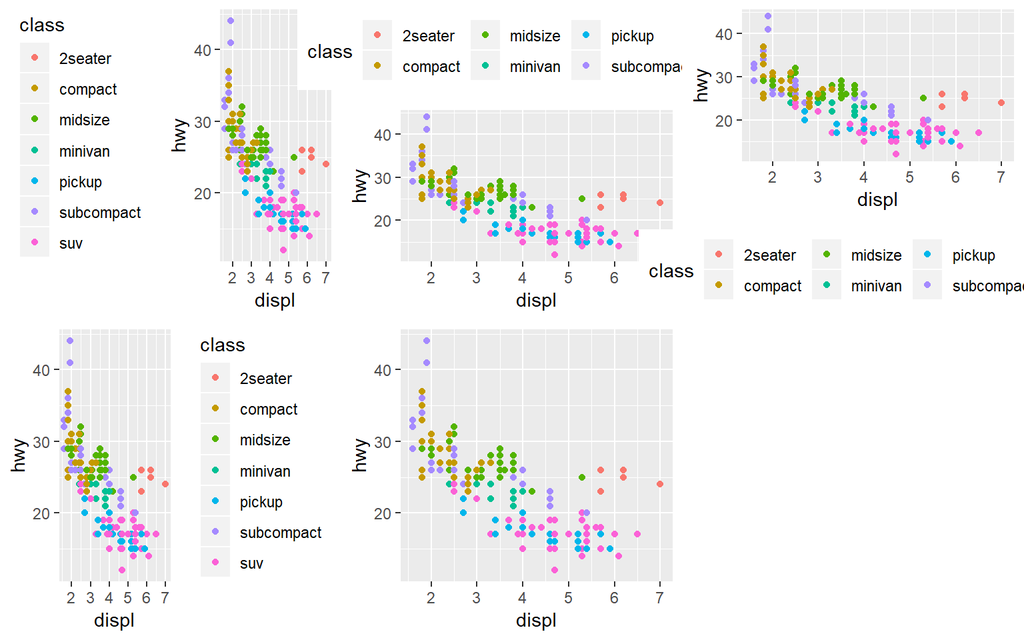

```r
base <- ggplot(mpg, aes(displ, hwy)) +
  geom_point(aes(color = class))

grid.arrange(
base + theme(legend.position = "left"),
base + theme(legend.position = "top"),
base + theme(legend.position = "bottom"),
base + theme(legend.position = "right"), # default
base + theme(legend.position = "none"),
nrow = 2)
```

개별 범례의 출력을 조정하기 위해, `guides()`를 `guide_legned()` or `guide_colorbar()`와 함께 사용한다. 다음 예제는 두 가지 중요한 설정을 보여준다: nrow로 범례의 행의 수를 통졔하고 점을 크게 만든다. 플랏에서 low alpha를 사용하면 특히 유용하다.

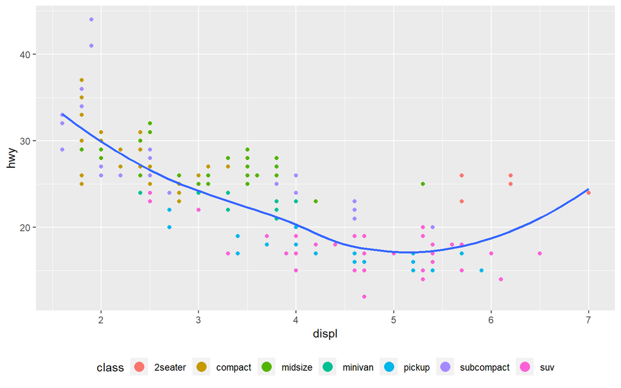

```r
ggplot(mpg, aes(displ, hwy)) +
  geom_point(aes(color = class)) +
  geom_smooth(se = FALSE) +
  theme(legend.position = "bottom") +
  guides(
    color = guide_legend(
      nrow = 1,
      override.aes = list(size = 4)
    )
  )
```

### 2.5.3 Replacing a Scale

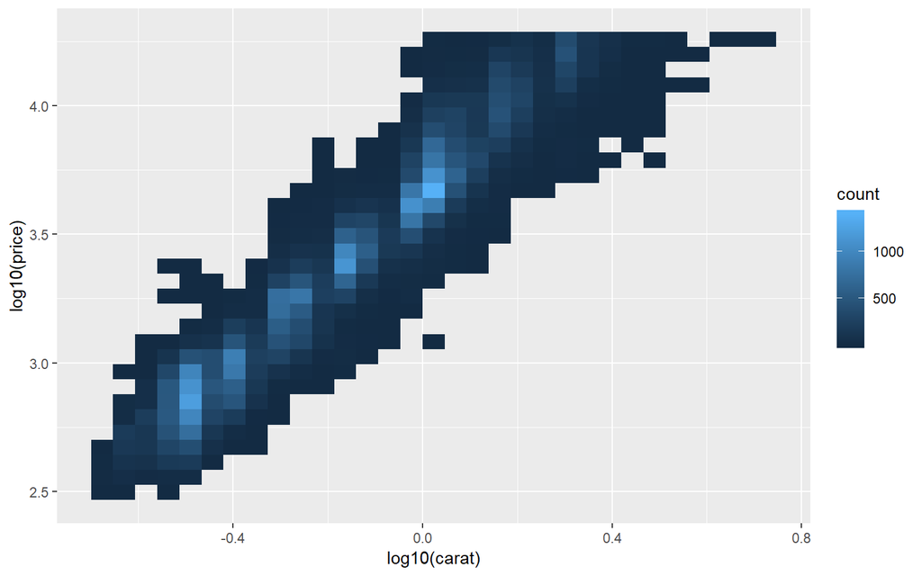

```r
ggplot(diamonds, aes(log10(carat), log10(price))) +
  geom_bin2d()
```

하지만 변환의 단점은 축이 변환된 값에서 레이블 되어서 해석하기 어렵다. 미적 요소 매칭에서 변환을 수행하는 대신에, 스케일에서 변환을 할 수 있다. 원본 데이터 스케일에서 레이블 되는 축을 제외하면 시각적으로 동일하다다.

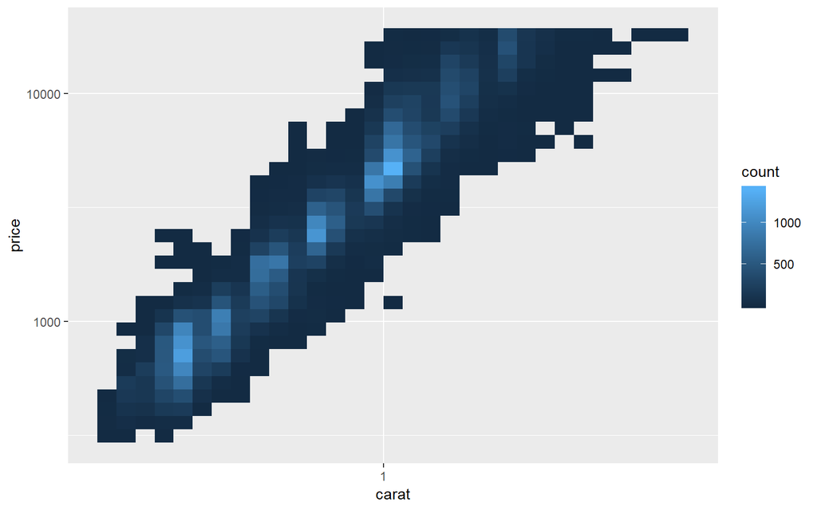

```r
ggplot(diamonds, aes(carat, price)) +
  geom_bin2d() +
  scale_x_log10() +
  scale_y_log10()
```

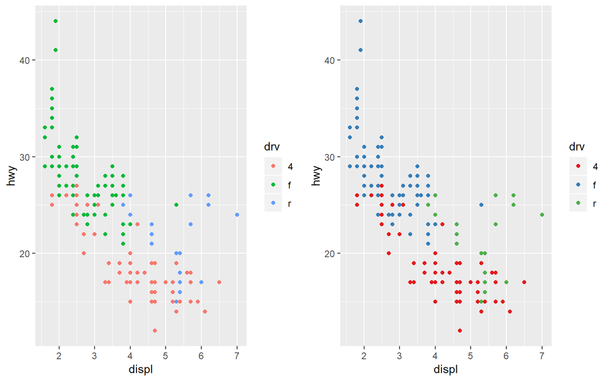

```r
grid.arrange(
ggplot(mpg, aes(displ, hwy)) +
  geom_point(aes(color = drv)),
ggplot(mpg, aes(displ, hwy)) +
  geom_point(aes(color = drv)) +
  scale_color_brewer(palette = "Set1"),
ncol = 2)
```